# Analysis of NOAA

Jaya Shankar G S

## Basic settings

```r
knitr::opts_chunk$set(echo = TRUE)
library(dplyr)
```

```r
library(ggplot2)
library(gridExtra)
```

## Data Processing

Here, we download the data and loading into a variable `storm_data`

```r
if(!file.exists("StormData.csv.bz2"))
{
  download.file("https://d396qusza40orc.cloudfront.net/repdata%2Fdata%2FStormData.csv.bz2",destfile = "/home/adler-jai/Documents/NOAA_document_analysis/StormData.csv.bz2")
}
```

We have 902297 rows and 37 columns in total and these are the first 6 observations

```r
storm_data <- read.csv("StormData.csv.bz2")
  dim(storm_data)
```

```
## [1] 902297     37
```

```r
  head(storm_data)
```

```
##   STATE__           BGN_DATE BGN_TIME TIME_ZONE COUNTY COUNTYNAME STATE  EVTYPE
## 1       1  4/18/1950 0:00:00     0130       CST     97     MOBILE    AL TORNADO
## 2       1  4/18/1950 0:00:00     0145       CST      3    BALDWIN    AL TORNADO
## 3       1  2/20/1951 0:00:00     1600       CST     57    FAYETTE    AL TORNADO
## 4       1   6/8/1951 0:00:00     0900       CST     89    MADISON    AL TORNADO
## 5       1 11/15/1951 0:00:00     1500       CST     43    CULLMAN    AL TORNADO
## 6       1 11/15/1951 0:00:00     2000       CST     77 LAUDERDALE    AL TORNADO
##   BGN_RANGE BGN_AZI BGN_LOCATI END_DATE END_TIME COUNTY_END COUNTYENDN
## 1         0                                               0         NA
## 2         0                                               0         NA
## 3         0                                               0         NA
## 4         0                                               0         NA
## 5         0                                               0         NA
## 6         0                                               0         NA
##   END_RANGE END_AZI END_LOCATI LENGTH WIDTH F MAG FATALITIES INJURIES PROPDMG
```

[output cut: 20 more lines]

## Analysis of Weather Events on Public Health

In this code chunk we take top 10 events that are responsible for causing severe damage on public health. In our data we have **FATALITIES** and **INJURIES** are variables that are recorded the public health damage, using these variables we find the events that are dangerous.

```r
agg1 <- aggregate(INJURIES~EVTYPE,FUN = sum,data = storm_data)
agg2 <- aggregate(FATALITIES~EVTYPE,FUN = sum, data = storm_data)
evinj <- filter(agg1, INJURIES != 0)
evfat <- filter(agg2, FATALITIES != 0)
fatalities <- arrange(evfat, desc(FATALITIES))[1:10,]
injuries <- arrange(evinj, desc(INJURIES))[1:10,]
```

## Analysis of Weather Events on Economy

The data `storm_data` consists the variables `CROPDMGEXP` and `PROPDMGEXP` describes the multiplier to `CROPDMG` and `PROPDMG` which is described in ([storm documentation](https://d396qusza40orc.cloudfront.net/repdata%2Fpeer2_doc%2Fpd01016005curr.pdf)). That is Hundreds(H),Thousands(K),Millions(M) and Billions(B). Example : If we have 5 in `CROPDMG` and M in `CROPDMGEXP` then the total is 5 millions. Like this we filter the data and takes the top 15 events affects most to economy.

```r
prop_dmg <- filter(select(storm_data,EVTYPE,PROPDMG,PROPDMGEXP),PROPDMG != 0)
crop_dmg <- filter(select(storm_data,EVTYPE,CROPDMG,CROPDMGEXP),CROPDMG != 0)
datahelper <- function(dataset){
dataset <- filter(dataset, dataset[,3] == "B" |dataset[,3] == "M"|dataset[,3] == "K"|dataset[,3] == "H" )
dataset[,3][toupper(dataset[,3]) == "B"] <- 10^9
dataset[,3][toupper(dataset[,3])== "M"] <- 10^6
dataset[,3][toupper(dataset[,3]) == "K"] <- 1000
dataset[,3][toupper(dataset[,3]) == "H"] <- 100
dataset[,3][toupper(dataset[,3]) == ""] <- 0
dataset$total <- dataset[,2] * as.numeric(dataset[,3])
return(dataset)
}
property <- datahelper(prop_dmg)
crop <- datahelper(crop_dmg)
propagg <- aggregate(total ~ EVTYPE,data = property,FUN = sum)
cropagg <- aggregate(total ~ EVTYPE,data = crop,FUN = sum)
evprop <-arrange(propagg, desc(total))[1:15,]
evcrop <- arrange(cropagg,desc(total))[1:15,]
```

## Results

Finally, we got the event type in two variables which affected the public badly.

```r
fatalities
```

```
##            EVTYPE FATALITIES
## 1         TORNADO       5633
## 2  EXCESSIVE HEAT       1903
## 3     FLASH FLOOD        978
## 4            HEAT        937
## 5       LIGHTNING        816
## 6       TSTM WIND        504
## 7           FLOOD        470
## 8     RIP CURRENT        368
## 9       HIGH WIND        248
## 10      AVALANCHE        224
```

```r
injuries
```

```
##               EVTYPE INJURIES
## 1            TORNADO    91346
## 2          TSTM WIND     6957
## 3              FLOOD     6789
## 4     EXCESSIVE HEAT     6525
## 5          LIGHTNING     5230
## 6               HEAT     2100
## 7          ICE STORM     1975
## 8        FLASH FLOOD     1777
## 9  THUNDERSTORM WIND     1488
## 10              HAIL     1361
```

Now, we are plotting the results. From the both plot we can say that **TORNADO** and **EXCESSIVE HEAT** are highly affected to the public health.

[figure not shown]

```r
fatal <- qplot(EVTYPE, data = fatalities, weight = FATALITIES, geom = "bar") +
  ylab("Number of Fatalities") +
  theme(axis.text.x = element_text(angle = 45, hjust = 1)) + xlab("Severe Weather Type") +
  ggtitle("Total Fatalities by Severe Weather Events")

injur <- qplot(EVTYPE, data = injuries, weight = INJURIES, geom = "bar") +
  ylab("Number of Fatalities") +
  theme(axis.text.x = element_text(angle = 45, hjust = 1)) + xlab("Severe Weather Type") +
  ggtitle("Total Injuries by Severe Weather Events")

 grid.arrange(fatal,injur, ncol = 2)
```

Now let us see how the weather events affected the economy. We stored the top events affected to economy in variables `evprop` and `evcrop`. **Property Damage** in Dollars

```r
evprop
```

```
##               EVTYPE        total
## 1              FLOOD 144657709800
## 2  HURRICANE/TYPHOON  69305840000
## 3            TORNADO  56925660480
## 4        STORM SURGE  43323536000
## 5        FLASH FLOOD  16140811510
## 6               HAIL  15727367220
## 7          HURRICANE  11868319010
## 8     TROPICAL STORM   7703890550
## 9       WINTER STORM   6688497250
## 10         HIGH WIND   5270046260
## 11       RIVER FLOOD   5118945500
## 12          WILDFIRE   4765114000
## 13  STORM SURGE/TIDE   4641188000
## 14         TSTM WIND   4484928440
## 15         ICE STORM   3944927810
```

**Crop Damage** in Dollars

```r
evcrop
```

```
##               EVTYPE       total
## 1            DROUGHT 13972566000
## 2              FLOOD  5661968450
## 3        RIVER FLOOD  5029459000
## 4          ICE STORM  5022113500
## 5               HAIL  3025537450
## 6          HURRICANE  2741910000
## 7  HURRICANE/TYPHOON  2607872800
## 8        FLASH FLOOD  1421317100
## 9       EXTREME COLD  1292973000
## 10      FROST/FREEZE  1094086000
## 11        HEAVY RAIN   733399800
## 12    TROPICAL STORM   678346000
## 13         HIGH WIND   638571300
## 14         TSTM WIND   554007350
## 15    EXCESSIVE HEAT   492402000
```

Plots of **Property Damage** and **Crop Damage**

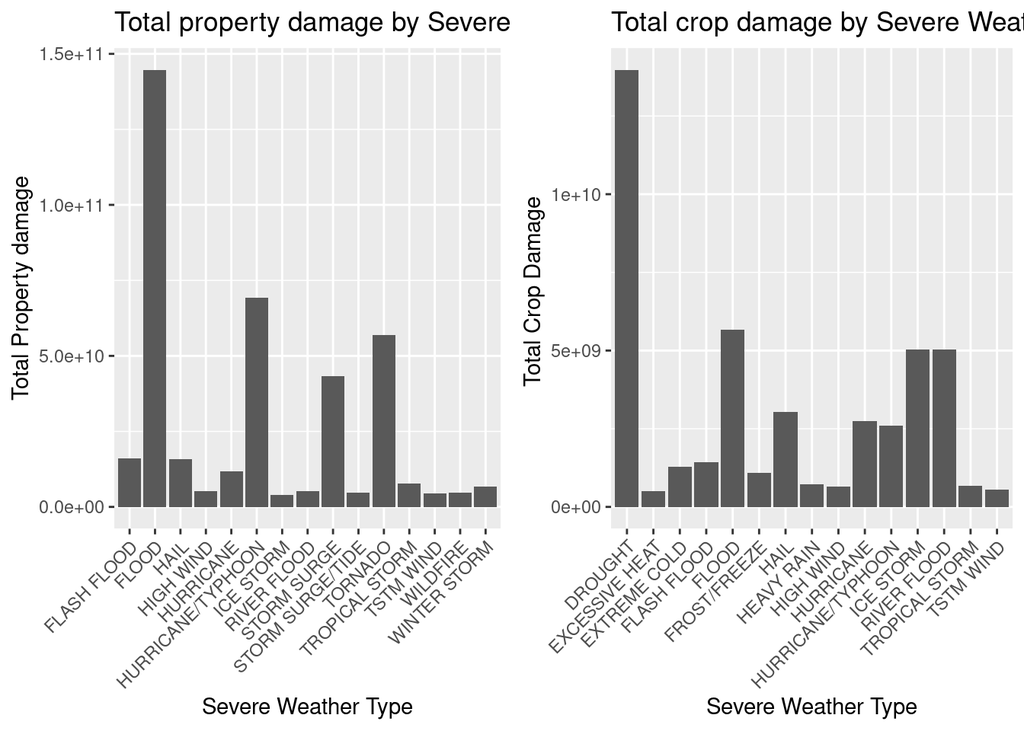

```r
prop <- qplot(x = EVTYPE,weight = total,data = evprop,geom = "bar") +
  ylab("Total Property damage") +
  theme(axis.text.x = element_text(angle = 45, hjust = 1)) +
  xlab("Severe Weather Type") +
  ggtitle("Total property damage by Severe Weather Events")

crops <- qplot(x  = EVTYPE, weight = total, data = evcrop, geom = "bar") +
  ylab("Total Crop Damage ") +
  theme(axis.text.x = element_text(angle = 45, hjust = 1)) +
  xlab("Severe Weather Type") +
  ggtitle("Total crop damage by Severe Weather Events")

grid.arrange(prop,crops, ncol = 2)
```